# Doğrusal modeller ve Logaritmik artış

Emrah Kırdök, Ph. D.

Nisan 30, 2021

## Doğrusal Modellere Giriş

Bu kısımda ise doğrusal modellere giriş yapacağız. Genel olarak doğadaki işleyişi anlamak için modeller kullanırız. Modeller aslında iki veya daha fazla değişken arasındaki ilişkiyi açıklayan denklemler olarak da ifade edilebilir. Doğrusal modeller bu ilişkinin en basit anlamda ifade edilmiş şekllerinden bir tanesidir.

Bunu şu şekilde açıklamaya çalışalım. Mesela ölçümler veri setinde taç yaprak uzunlukları ve taç yaprak genişliklerini bir grafik üzerinde ifade edelim. Taç yaprak uzunlukları y ekseninde, taç yaprak genişlikleri ise x ekseninde olsun:

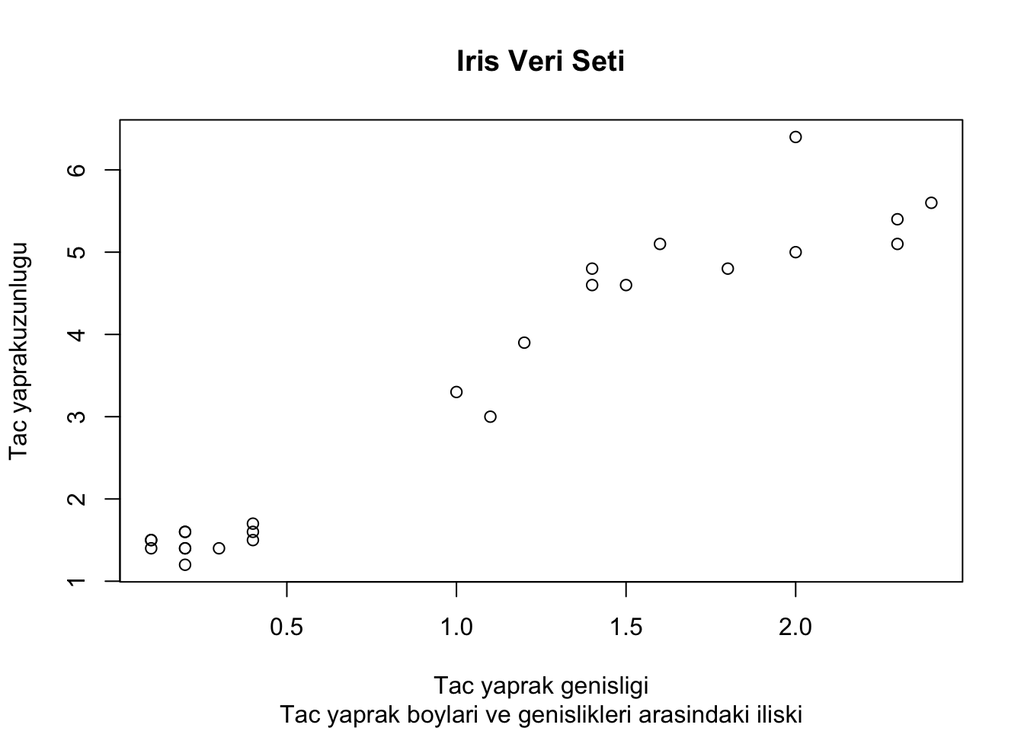

```r
plot(olcumler$tac.uzunluk ~ olcumler$tac.genislik,
     main="Iris Veri Seti",
     sub = "Tac yaprak boylari ve genislikleri arasindaki iliski",
     xlab="Tac yaprak genisligi", ylab="Tac yaprakuzunlugu")
```

Eğer bu grafiğe dikkat ederseniz, taç yaprakların genişlikleri arttıkça boylarının da arttığını görebilirsiniz. Yani bu iki değişken birbirleriyle aynı yönde doğrusal bir ilişki içerisinde. Bu ilişkiyi bir denklem kullanarak ifade edebiliriz.

Doğrusal modeller, birbirleriye ilişkide olan iki farklı veri setini en iyi şekilde ifade edebilen bir denklem oluşturmamızı sağlar. Bu aslında en basit şekliyle bir eğim çizgisi olarak da ifade edilebilir.

Öncekli derslerden hatırlarsak, eğim çizgisi çizmek için `abline` fonksiyonunu kullanabiliriz:

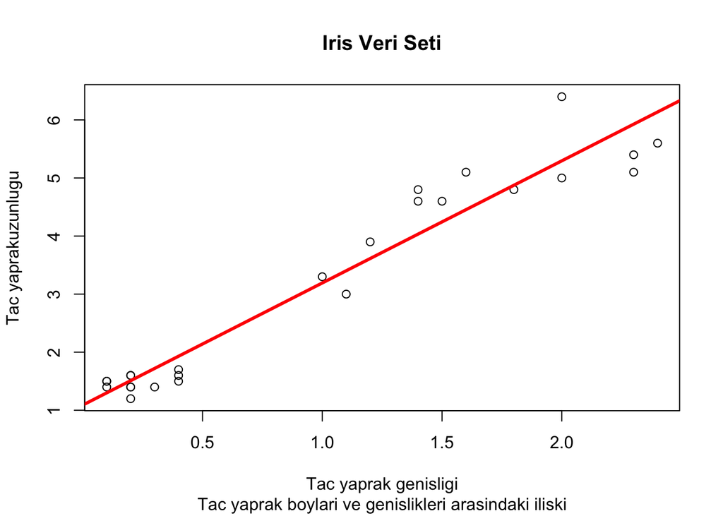

```r
plot(olcumler$tac.uzunluk ~ olcumler$tac.genislik,
     main="Iris Veri Seti",
     sub = "Tac yaprak boylari ve genislikleri arasindaki iliski",
     xlab="Tac yaprak genisligi", ylab="Tac yaprakuzunlugu")
abline(a = 1.089573, b = 2.103253, col="red", lwd=3)
```

Yukarıda `abline` fonksiyonunun içerisine yazdığımız değerlere bakalım. Analitik geometri derslerinden hatırlarsanız bir doğru denklemini şu şekilde yazıyorduk:

$$y=bx+a$$

Bu şekilde ifade edilen bir doğruyu çizmek için önce $x$ değerine $0$ verip, $y$ değerini elde ediyorduk ve $y$ eksenine bir nokta koyuyorduk. Ardından da $x$ değerine $1$ verip ikinci bir nokta elde ederek doğrumuzu çiziyotduk.

Dikkat ederseniz `abline` fonksiyonu içerisinde de $b$ ve $a$ değerleri bulunmaktadır. Bu değerleri bir doğru denklemi olarak ifade edersek:

$$y = 2.103253\cdot b + 1.089573$$

Şeklinde yazabiliriz. Yani aslında `abline` fonksiyonunu kullanarak, bu veri setindeki doğrusal ilişkiyi anlatan en iyi çizgiyi çizdik. Ancak bunu bilinen katsayı değerleri kullanarak yaptık. İşte bu derste, bu formülü kendimiz nasıl oluşturabileceğimizi göreceğiz.

### Doğrusal modelleme: en uygun doğruyu seçmek

R üzerinde `lm` isimli fonksiyonu kullanarak, elimizdeki veri setini en iyi ifade eden doğrusal denklemi elde edebiliriz. Örnek vermek gerekirse, taç yaprak uzunluklarını, taç yaprak genişliği kullanarak ifade eden bir model oluşturalım:

```r
model <- lm(tac.uzunluk ~ tac.genislik, data=olcumler)
```

Burada yazdığımız denklem aslında $y = bx + a$ ya da $tac.uzunluk = b\cdot tac.genislik + a$ anlamına gelmektedir. Yani taç yaprak uzunluklarını, taç yaprak genislikleri kullanarak modelledik. R bu modelü oluştururken rastgele doğrular çizer ve her noktanın bu doğruya olan uzaklığının karelerini toplar. Bu işleme kareler toplamı adı verilir. Bu değerin en küçük olduğu doğru, bu noktaları en iyi şekilde ifade eden denklem olur.

Yani, yukarıda gördüğümüz katsayıları R kendisi hesaplayarak buluyor. Peki katsayıları elde edebilir miyiz? Evet, `coef` fonksiyonunu kullanarak bunu yapabiliriz:

```r
coef(model)
```

```
##  (Intercept) tac.genislik
##     1.089573     2.103253
```

Burada `Intercept`, aslında formulde $a$ olarak belirtilen katsayıya denk geliyor. Yani $x=0$ olduğunda, $y$’nin aldığı değer. `tac.genislik` ise $b$ olarak ifade edilen eğim katsayısı.

Peki bu modeli grafikte nasıl gösterebiliriz? Daha önce yaptığımız gibi katsayıları `abline` fonksiyonu içerisinde kullanabiliriz. Ya da doğrudan oluşturduğumuz modeli `abline` fonksiyonu içerisine de yazabiliriz:

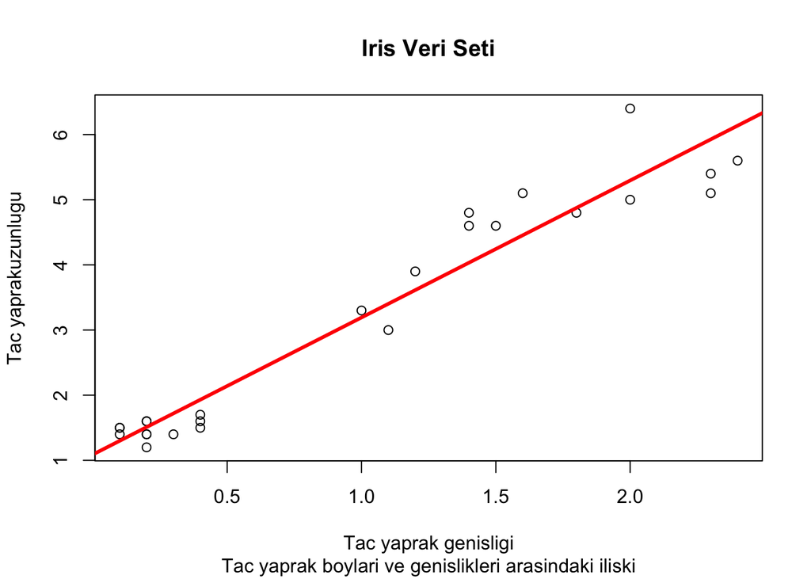

```r
plot(olcumler$tac.uzunluk ~ olcumler$tac.genislik,
     main="Iris Veri Seti",
     sub = "Tac yaprak boylari ve genislikleri arasindaki iliski",
     xlab="Tac yaprak genisligi", ylab="Tac yaprakuzunlugu")
abline(model, col="red", lwd=3)
```

Şimdi sıra model hakkında daha fazla bilgi almaya geldi. Oluşturduğumuz model belli çerçeveler içerisinde güvenilir olarak kullanılabilir. Teorik olarak sınırsız sayıda modelleme çalışması yapabilirisiniz. Ancak bu her zaman anlamlı modeller oluşturacağınız anlamına gelmez. Modellerden elde ettiğiniz katsayıları ve diğer istatistiksel bilgileri inceleyerek, modellerinizin güvenirliği hakkında çıkarımlarda bulunmanız gerekir.

R içerisinde `summary` fonksiyonunu modellere uyguladığınızda, o model hakkında ayrıntılı bilgiler elde edebilirsiniz:

```r
summary(model)
```

```
##
## Call:
## lm(formula = tac.uzunluk ~ tac.genislik, data = olcumler)
##
## Residuals:
##      Min       1Q   Median       3Q      Max
## -0.82705 -0.32055 -0.07543  0.20010  1.10392
##
## Coefficients:
##              Estimate Std. Error t value Pr(>|t|)
## (Intercept)    1.0896     0.1473   7.397  1.6e-07 ***
## tac.genislik   2.1033     0.1154  18.231  3.6e-15 ***
## ---
## Signif. codes:  0 '***' 0.001 '**' 0.01 '*' 0.05 '.' 0.1 ' ' 1
##
## Residual standard error: 0.4637 on 23 degrees of freedom
## Multiple R-squared:  0.9353, Adjusted R-squared:  0.9325
## F-statistic: 332.4 on 1 and 23 DF,  p-value: 3.602e-15
```

Karşımıza beş panelden oluşan bir özet tablosu çıktı. Hepsini inceleyelim:

**Call** kısmı, yazdığımız komutu bize gösteren bir panel.

**Residuals** kısmı, veri noktalarının, çizdiğimiz doğruya olan uzaklıklarının dağılımını gösterir. İdeal bir modelde minimum ve maximum değerlerinin simetrik bir şekilde olması beklenir. Yani yaklaşık 0’a denk gelen bir ortanca değerin etrafında simetrik bir dağılım bekleniyor.

**Coefficients** kısmı ise katsayıların gösterildiği kısım. Burada dikkat etmemiz gereken `tac.genislik` değişkeni için elde edilen değerler. Estimate, model tarafından tahmin edilen değerleri ifade ediyor. Std Error, bu derğerlerin standart hatasını ve Pr ise, bu tahminin istatistiksel gücünü ifade ediyor. Genel olarak 0.001 - 0.05 arasında bir anlamlılık değeri elde etmeyi bekleriz. Elde ettiğimiz sonuç, 0.001’e göre anlamlı çıkmıştır. **Pr** ya da **p-value** değeri ne kadar küçük olursa, o kadar anlamlı bir sonuç elde ettiğimizi gösterir.

**Signif. codes** paneli ise, p-value değerlerinini işaretler ile gösterilmiş hali.

Son panele bakarsak dikkat etmemiz gereken iki nokta var. Adjusted R-squeared değeri, bize oluşturulan modelin, bütün verinin yüzde kaçını temsil ettiğini gösteren bir değerdir. Burada bizim oluştruduğumuz model, bütün veri setnin 93%’sini temsil ediyor. Yani oldukça açıklayıcı bir model elde etmişiz.

### Geleceği tahmin etmek…

Hiç kuşkusuz modelleme çalışmalarının en heyacan verici yanı, oluşturulan modeller kullanılarak tahminler yapabilmemizdir. Mesela basit bir örnek olarak, oluşturduğumuz modeli inceleyerek bazı tahminlerde bulunalım.

Sizin için küçük bir veri seti oluştrudum. Bu verileri aldığımız `iris` veri setini kullanarak, *virginica* bitkisine ait bazı taç yaprak genişliği ölçümleri belirledim. Bu veriler, bizim `olcumler` veri setinde yok. Dolayısıyla, tahminlerimizi karşılaştırıp, ne kadar hata yaptığımızı hesaplayabiliriz.

Amacımız, *virginica* bitkisindeki taç yaprak genişliklerini oluştruduğumuz model içerisinde kullanarak, taç yaprak uzunluklarını hesaplamak olacak. Şimdi oluşturduğumuz örnek veri setini inceleyelim:

```r
virginica_altkume <- iris[c(130,145, 147),]
colnames(virginica_altkume) <- c("canak.uzunluk", "canak.genislik", "tac.uzunluk", "tac.genislik", "tur")
kable(virginica_altkume)
```

|  | canak.uzunluk | canak.genislik | tac.uzunluk | tac.genislik | tur |
| --- | --- | --- | --- | --- | --- |
| 130 | 7.2 | 3.0 | 5.8 | 1.6 | virginica |
| 145 | 6.7 | 3.3 | 5.7 | 2.5 | virginica |
| 147 | 6.3 | 2.5 | 5.0 | 1.9 | virginica |

Bir model kullanarak tahminde bulunmak için, modeli oluşturduğumuz veri setine eş bir veri çerçevesi kullanmalıyız. Bu yüzden `tac.genislik` isminde bir veri çerçevesi oluşturuyorum:

```r
tac.genislik <- data.frame(tac.genislik=virginica_altkume$tac.genislik)
```

Burada sütun isimlerinin birbirleriyle eşleşmesi gerekmektedir. Şimdi `predict` fonksiyonu ile tahminde bulunabiliriz:

```r
predict(model, tac.genislik)
```

```
##        1        2        3
## 4.454778 6.347705 5.085754
```

Evet, işte tahminlerimizin sonucunda elde ettiğimiz değerler. İsterseniz bir kontrol edelim tahminlerimiz ne kadar doğru:

```r
tahmin <- predict(model, tac.genislik)
veri <- data.frame(gercek.uzunluk=virginica_altkume$tac.uzunluk, tahmin.uzunluk=tahmin)
kable(veri)
```

| gercek.uzunluk | tahmin.uzunluk |
| --- | --- |
| 5.8 | 4.454778 |
| 5.7 | 6.347705 |
| 5.0 | 5.085754 |

Eh, çok iyi olmasa da tahmin edebilmişiz. Bu derste gördüğünüz örneği diğer yaprak uzunlukları için uygulayabilir misiniz?

## Üssel artışı modellemek

Ancak doğaya baktığınızda her modelin doğrusal bir nitelik taşımadığını görebilirsiniz. Genel olarak iki değişkenin arasındaki ilişki doğru orantılı bir şekilde gerçekleşmez. Mesela bakteri kültürlerindeki hücrelerin büyüme modelini inceleyelim.

Çalışmalar bir *E. coli* bakterisinin yaklaşık 20 dakikada bir bölündüğü gösterilmiştir. Eğer bunu matematiksel olarak ifade edersek:

$$\texttt{hucre[t]} = \texttt{baslangic} \cdot \texttt{oran}^\texttt{adim}$$

Bu formül üzerinden şöyle bir örnek geliştirelim. 10 tane *E. coli* hücresini 30 adım boyunca kültürleyelim. Burada *adim* değişkeni 20 dakikalık zaman dilimlerini temsik etmektedir. Bütün değerleri formülümüze yerleştirelim:

```r
adim <- seq(1,30)
hucre_sayisi <- 10*2^adim
```

Şimdi, elde ettiğimiz değerleri bir tablo üzerinde gösterelim.

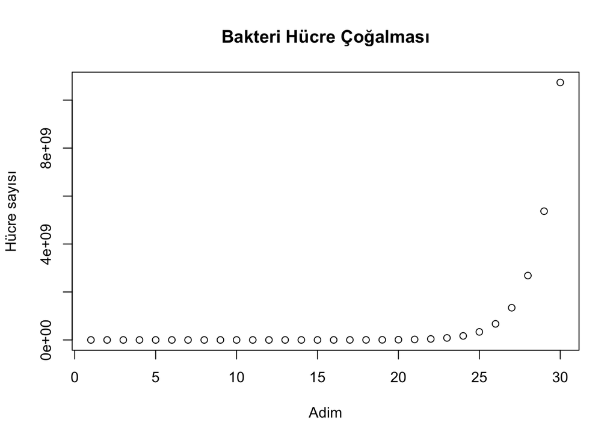

```r
plot(hucre_sayisi~adim,
     main = "Bakteri Hücre Çoğalması",
     xlab = "Adim",
     ylab = "Hücre sayısı")
```

Dikkat ederseniz bakterilerde hücre çoğalması doğrusal bir şekilde ifade edilemiyor. İlk adımdaki değerler sıfıra yakınken, son adımlarda hücre çoğalması çok hızlı bir artış gösteriyor. Bu tip bir artışa *üssel* artış adı veriyoruz. Ancak böyle bir ilişkiyi modellemek istersek işimiz çok zor olacaktır. Bunun için geliştirilen çözümlerden bir tanesi, hücre sayısı verisini logaritmik ölçekte ifade etmektir. Peki nasıl yapacağız? Önce bir yukarda yazdığımız formülü hatırlayalım:

$$\texttt{hucre[t]} = \texttt{baslangic} \cdot \texttt{oran}^\texttt{adim}$$

Bu formülde her iki tarafın da logaritmasını alalım:

$$log(hucre[t]) = log(baslangic \cdot oran^{adim})$$

Matematik derslerinden hatırlarsaınız, eğer bir ifadenin logaritmasını alıyorsak, çarpım işlemi toplama işlemine dönüşür. Ayrıca eğer ifadenin içerisinde üs varsa, onlar da katsayı olarak denkleme dahil edilir. Dolayısıyla aşağıdaki eşitliği elde etmiş oluyoruz:

$$log(hucre[t]) = log(baslangic) + adim \cdot oran$$

Dikkat ederseniz aslında bir doğru denklemi elde ettik. Burada $log(baslangic)$ ifadesi *intercept* konumuna geldi. Yani $x=0$ olduğunda $y$’nin aldığı değer. $adim \cdot oran$ ise eğrimizin eğimini tanımlayan ifade oldu. Yani tek bir işlemler üssel bir fonksiyonu, doğrusal bir fonksiyon haline getirdik. Ancak burada logaritma olarak ifade ettiğimiz değer, aslında doğal logaritmadır.

Şimdi bu yaptığımızı veri üzerinde uygulayalım. Önce `hucre_sayısı` ifadesinin logaritmasını alıp bunu `hucre_sayisi_log` değişkeni içerisine aktaralım:

```r
hucre_sayisi_log <- log(hucre_sayisi)
```

Şimdi de `hucre_sayisi_log` ve `adim` değişkenlerinin grafiğini çizelim:

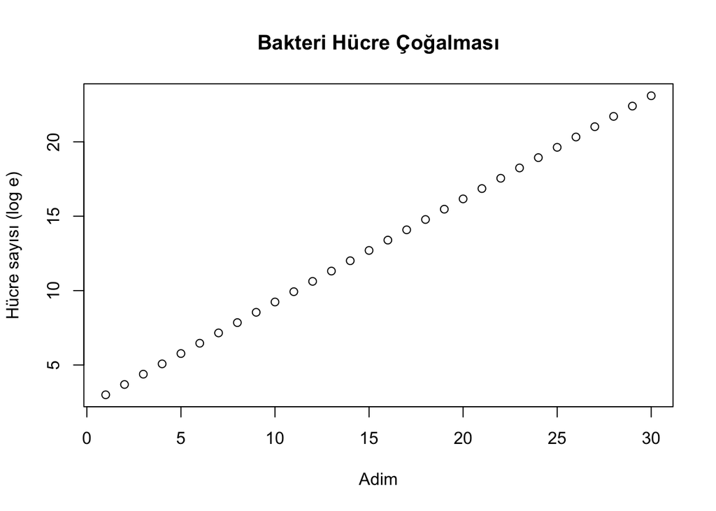

```r
plot(log(hucre_sayisi)~adim,
     main = "Bakteri Hücre Çoğalması",
     xlab = "Adim",
     ylab = "Hücre sayısı (log e)")
```

Dikkat ederseniz artık elimizde doğrusal bir grafik var. İsterseniz bir de bu iki grafiği yan yana koyup inceleyelim:

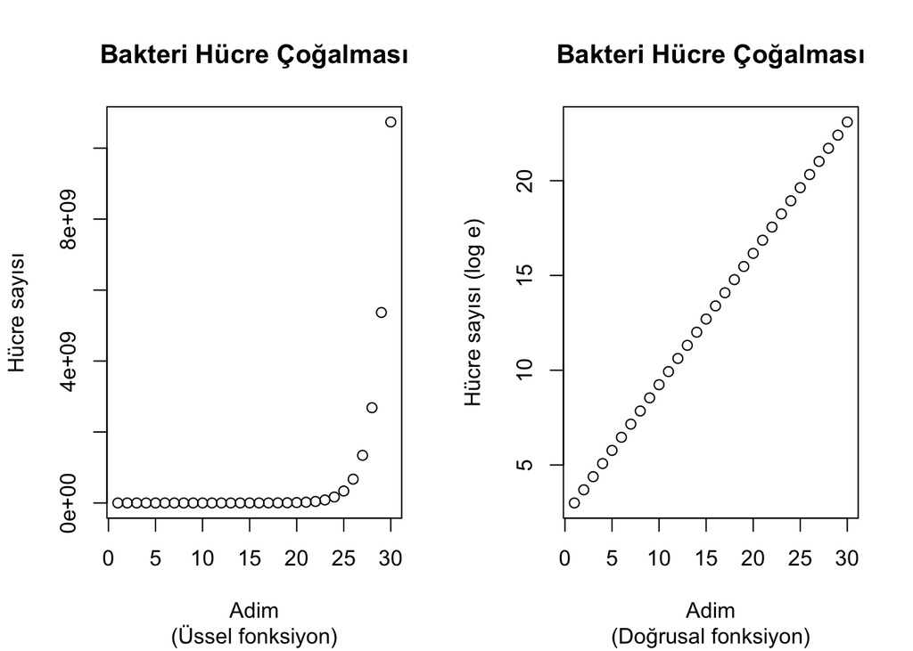

```r
par(mfrow = c(1,2))

plot(hucre_sayisi~adim,
     main = "Bakteri Hücre Çoğalması",
     sub = "(Üssel fonksiyon)",
     xlab = "Adim",
     ylab = "Hücre sayısı")

plot(log(hucre_sayisi)~adim,
     main = "Bakteri Hücre Çoğalması",
     sub = "(Doğrusal fonksiyon)",
     xlab = "Adim",
     ylab = "Hücre sayısı (log e)")
```

### Doğrusal modellerin pratik bir uygulaması: Salgınları anlamak

Peki bu tip bir dönüşüm bize ne fayda sağlayacak? Son günlerde yaşadığımız Covid salgınını düşünün. Eğer grafikleri incelerseniz, vaka sayısındaki artışın üssel olduğunu göreceksiniz. Yani, vaka sayısı belirli periyotlar haline iki katına çıkıyor. Bu ders için Covid salgının DÜnya’daki seyri için bir veri seti hazırladım.

Önce veri setini yükleyelim:

```r
covid <- read.table("data/covid.txt", header=T)
```

```r
head(covid)
```

```
##        tarih toplam_vaka gun
## 1 2019-12-31          27   1
## 2 2020-01-01          27   2
## 3 2020-01-02          27   3
## 4 2020-01-03          44   4
## 5 2020-01-04          44   5
## 6 2020-01-05          59   6
```

İlk sütun tarihlerin saklandığı bir vektör, ikinci sütun ise toplam vaka sayısını gösteriyor ve üçüncü sütun ise 31 Aralık 2019’dan itibaren kaç gün geçtiğini gösteriyor.

Veri seti üzerinde ilk 40 günkü verilere odaklanalım:

```r
covid_altkume <- covid[1:40,]
```

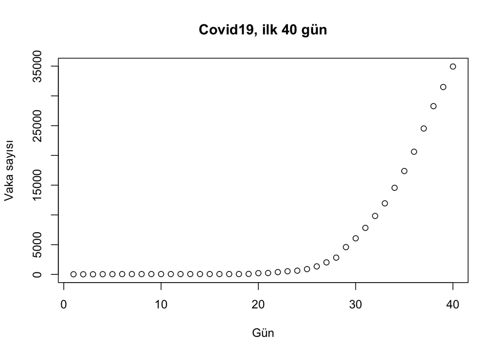

```r
plot(covid_altkume$toplam_vaka~covid_altkume$gun,
     main = "Covid19, ilk 40 gün",
     xlab = "Gün",
     ylab = "Vaka sayısı")
```

Dikkat ederseniz elimizde doğrusal bir artış yok. İlk 25 günde vaka sayısı yatay bir seyir izlerken, daha sonra üssel bir artış göstermiş. Eğer bu artışı daha yakından incelemek istersek, vaka sayısını logaritmik eksende ifade etmemiz gerekir. İsterseniz `covid_altkume` veri setine `log` isminde yeni bir sütun ekleyelim:

```r
covid_altkume$log <- log(covid_altkume$toplam_vaka)
```

Şimdi de oluşturduğumuz yeni vektörü grafik olarak gösterelim:

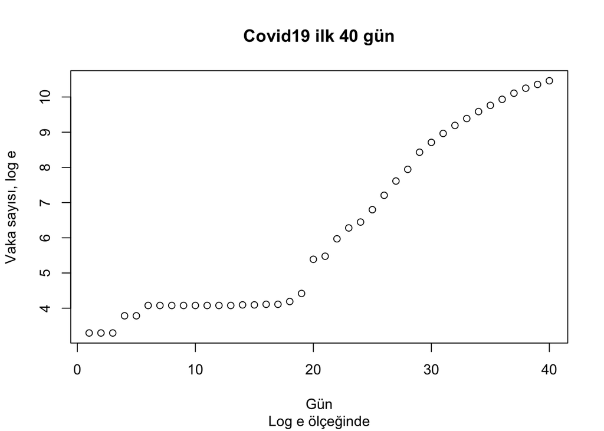

```r
plot(covid_altkume$log~covid_altkume$gun,
     main = "Covid19 ilk 40 gün",
     sub = "Log e ölçeğinde",
     xlab = "Gün",
     ylab = "Vaka sayısı, log e")
```

Dikkat ederseniz artık ilk günlerdeki artışı hakkında daha fazla bir fikrimiz oldu. Mükkemmel olmasa da artık elimizde birbirleriyle doğrusal ilişkide olan iki değişken bulunmakta. Artık bu bilgileri kullanarak iki değişken arasında bir doğrusal denklem ifade edebiliriz:

```r
model <- lm(log~gun, data=covid_altkume)
```

Önce oluşturduğumuz modelin katsayılarına bakalım:

```r
coefficients(model)
```

```
## (Intercept)         gun
##   1.9922501   0.2069248
```

Gün değişkeni için katsayının 0.2 olduğunu görüyoruz. Bu değerler bize, covid virüsunun ilk kırk gün boyunca her gün 0.2 kat arttığını göstermektedir.

Peki bir de modelin özetine bakalım:

```r
summary(model)
```

```
##
## Call:
## lm(formula = log ~ gun, data = covid_altkume)
##
## Residuals:
##     Min      1Q  Median      3Q     Max
## -1.5272 -0.5267  0.2074  0.5579  1.0967
##
## Coefficients:
##             Estimate Std. Error t value Pr(>|t|)
## (Intercept)  1.99225    0.23682   8.413  3.3e-10 ***
## gun          0.20692    0.01007  20.557  < 2e-16 ***
## ---
## Signif. codes:  0 '***' 0.001 '**' 0.01 '*' 0.05 '.' 0.1 ' ' 1
##
## Residual standard error: 0.7349 on 38 degrees of freedom
## Multiple R-squared:  0.9175, Adjusted R-squared:  0.9153
## F-statistic: 422.6 on 1 and 38 DF,  p-value: < 2.2e-16
```

Burada bakmamız gereken en önemli değerler:

- `gun` değişkeninin eğimi: 0.2
- Anlamlılık değeri (Pr)
- Adjusted R-squared değeri

Adjusted R-squared değeri bize, oluşturulan model bütün veri setinin %91’ini ifade ettiğini gösterir. Ve bu model p<0.001’e göre anlamlıdır.

Şimdi bu modeli, grafiğimize çizdirelim:

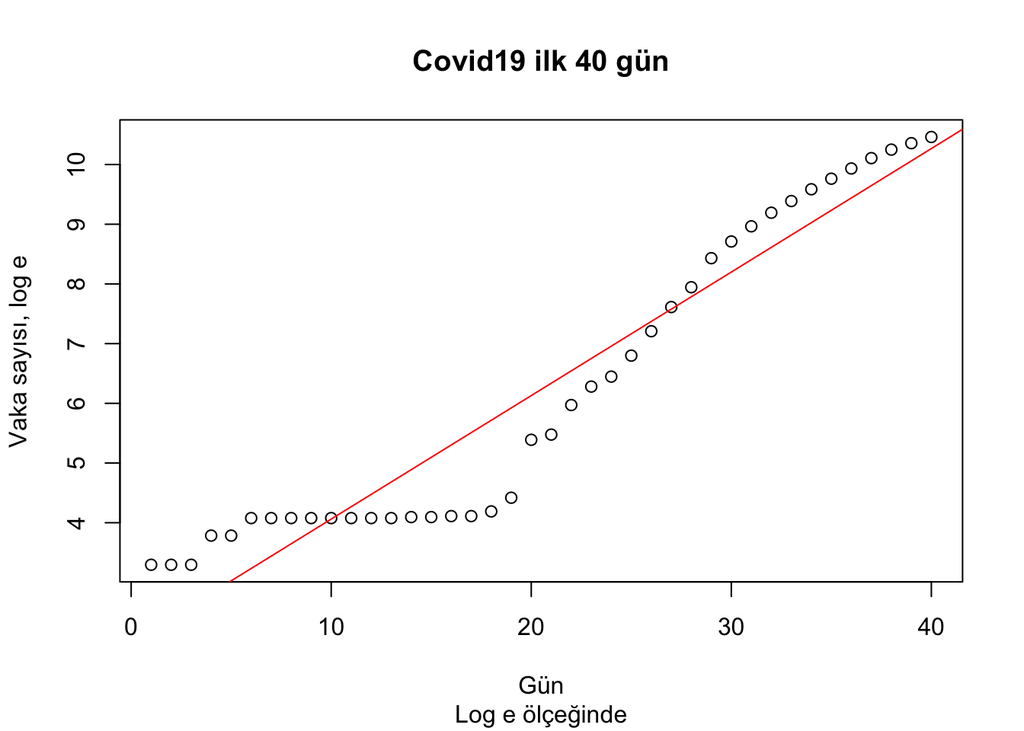

```r
plot(covid_altkume$log~covid_altkume$gun,
     main = "Covid19 ilk 40 gün",
     sub = "Log e ölçeğinde",
     xlab = "Gün",
     ylab = "Vaka sayısı, log e")

abline(model, col = "red")
```

İlk günlerde model çok iyi olmasa da, 20 günden sonra veriyi güzel bir şekilde ifade ediyor.

### Geleceği tahmin etmek

Peki bu modeli kullanarak geleceği tahmin edebilir miyiz? Mesela ilerleyen 5 gün için bir tahminde bulunalım:

```r
tahmin<-data.frame(gun=c(41,42,43,44,45))
tahmin$log_toplam_vaka <- predict(object = model, newdata = tahmin)
```

Burada model kullanarak ilerleyen 5 gün için bir tahminde bulunduk. Bu verilere bakalım:

```r
kable(tahmin)
```

| gun | log_toplam_vaka |
| --- | --- |
| 41 | 10.47617 |
| 42 | 10.68309 |
| 43 | 10.89002 |
| 44 | 11.09694 |
| 45 | 11.30387 |

Ancak dikkat ederseniz, bu tahmin verileri log ölçeğinde. Bu ölçeği tekrar eski haline getirmek için ise `exp` fonksiyonu kullanarak, eski haline döndürmemiz gerek:

```r
tahmin$toplam_vaka<-exp(tahmin$log_toplam_vaka)
kable(tahmin)
```

| gun | log_toplam_vaka | toplam_vaka |
| --- | --- | --- |
| 41 | 10.47617 | 35460.28 |
| 42 | 10.68309 | 43612.25 |
| 43 | 10.89002 | 53638.27 |
| 44 | 11.09694 | 65969.18 |
| 45 | 11.30387 | 81134.85 |

Evet şimdi anlaşılır bir halde. Peki tahminlerimiz gerçek verilerle ne kadar uyuşuyor? 41 ile 45. günlere ait toplama vaka verilerini alalım:

```r
tahmin$gercek_veri <- covid$toplam_vaka[41:45]
kable(tahmin)
```

| gun | log_toplam_vaka | toplam_vaka | gercek_veri |
| --- | --- | --- | --- |
| 41 | 10.47617 | 35460.28 | 37552 |
| 42 | 10.68309 | 43612.25 | 40540 |
| 43 | 10.89002 | 53638.27 | 43105 |
| 44 | 11.09694 | 65969.18 | 45177 |
| 45 | 11.30387 | 81134.85 | 60328 |